# Variação espacial

# Natureza da variação espacial

# Modelo discreto de variação espacial

## Modelo discreto: visão determinística

Carregar o mapa pedológico e gerar figura. No MS Windows, usar o argumento `encoding = 'UTF-8'` na função `raster::shapefile` para reconhecer carácteres especiais.

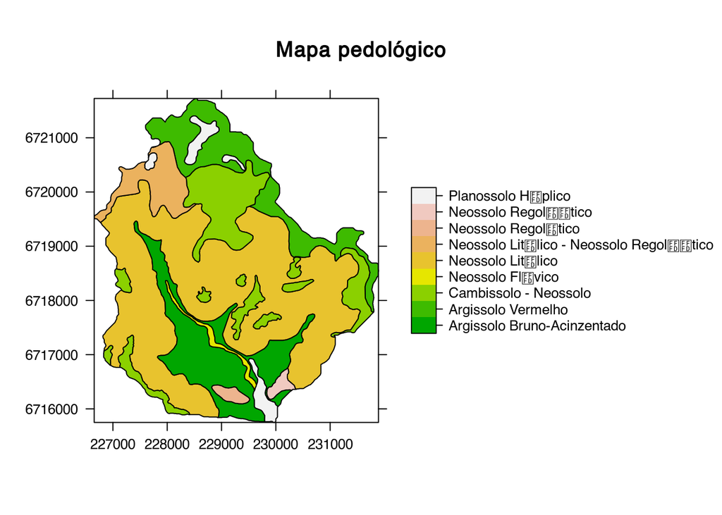

```r
pedologia25 <-
  raster::shapefile('../data/pedologia25.shp', stringsAsFactors = TRUE, encoding = 'UTF-8') %>%
  sp::spTransform(wgs84utm22s)
sp::spplot(
  pedologia25, scales = list(draw = TRUE),
  col.regions = terrain.colors(nlevels(pedologia25$um)),
  main = "Mapa pedológico")
```

Descarregar dados do conjunto de dados `ctbo0030`:

```r
perfis25_o <- febr::observations('ctb0030', which.cols = 'all')
perfis25_l <- febr::layers('ctb0030', which.cols = 'all', missing.data = 'keep')
id <- c('dataset_id', 'observacao_id')
perfis25 <-
  merge(x = perfis25_o, y = perfis25_l, by.x = id, by.y = id) %>%
  select(observacao_id, coord_x, coord_y, taxon_sibcs_2009, ca_kcl_aas, areia_, argila_)
rm(perfis25_l, perfis25_o)
```

Criar objeto espacial com os perfis e gerar figura.

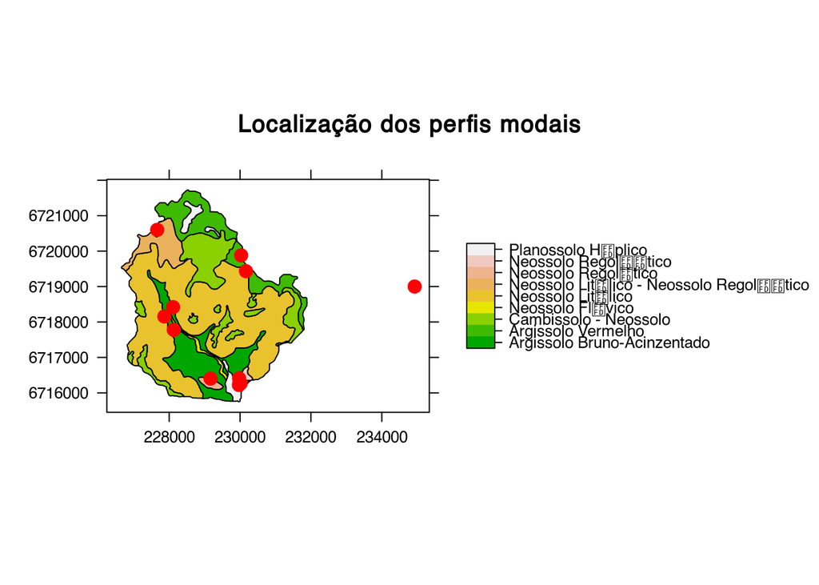

[output not shown]

```r
sp::coordinates(perfis25) <- c('coord_x', 'coord_y')
sp::proj4string(perfis25) <- wgs84
perfis25 <- sp::spTransform(perfis25, wgs84utm22s)
sp::spplot(
  pedologia25, scales = list(draw = TRUE),
  xlim = extendrange(c(perfis25@bbox[1, ], pedologia25@bbox[1, ])),
  ylim = extendrange(c(perfis25@bbox[2, ], pedologia25@bbox[2, ])),
  col.regions = terrain.colors(nlevels(pedologia25$um)),
  main = "Localização dos perfis modais") +
  lattice::xyplot(coord_y ~ coord_x, data = as.data.frame(perfis25@coords),
                  pch = 20, col = 'red', lwd = 2, cex = 2) %>%
  latticeExtra::as.layer()
```

## Modelo discreto: visão estocástica

```r
pontos400_o <- febr::observations('ctb0003', which.cols = 'all')
pontos400_l <- febr::layers('ctb0003', which.cols = 'all', missing.data = 'keep')
id <- c('dataset_id', 'observacao_id')
pontos400 <-
  merge(pontos400_o, pontos400_l, by.x = id, by.y = id) %>%
  select(observacao_id, coord_x, coord_y, taxon_sibcs_2009, ca_kcl_aas, argila_, areia_)
rm(pontos400_l, pontos400_o)
```

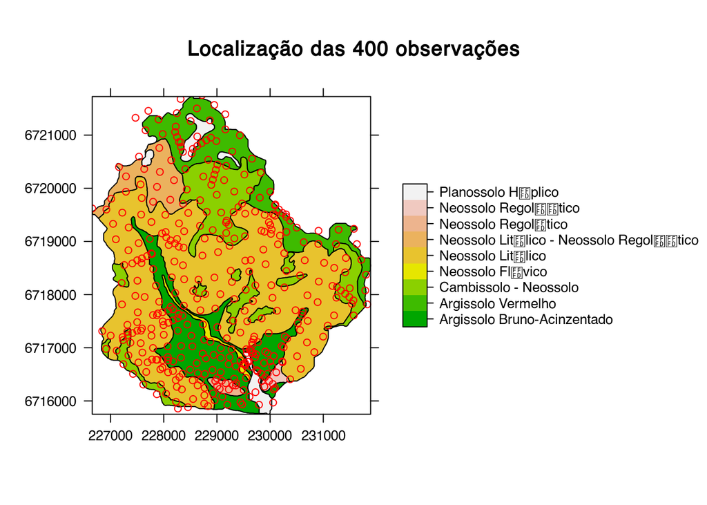

```r
sp::coordinates(pontos400) <- ~ coord_x + coord_y
sp::proj4string(pontos400) <- wgs84
pontos400 <- sp::spTransform(pontos400, wgs84utm22s)
sp::spplot(
  pedologia25, scales = list(draw = TRUE),
  col.regions = terrain.colors(nlevels(pedologia25$um)),
  main = "Localização das 400 observações") +
  lattice::xyplot(coord_y ~ coord_x,
                  data = pontos400@coords %>% as.data.frame(), pch = 21, col = 'red') %>%
  latticeExtra::as.layer()
```

Nós podemos calcular a média e desvio padrão da variável de interesse para cada categoria a partir das observações do solo que estão dentro de cada categoria. Mas primeiro temos que identificar a categoria dentro da qual cada observação do solo se encontra. Para isso usamos a função `sp::over` e armazenamos o resultado em uma nova coluna de `pontos400` chamada `um`. Assumindo que nossa amostra é grande o suficiente, que as observações são independetes, e que a variável de interesse possui distribuição nomal, calculamos o erro padrão (EP) da média para obter os limites inferior e superior do intervalo de confiança de 95%.

Calcular estatísticas de uma variável do solo para cada unidade de mapeamento.

```r
pontos400$um <- sp::over(x = pontos400, y = pedologia25) %>% unlist()
pontos400@data %>%
  filter(!is.na(um)) %>%
  group_by(um) %>%
  summarise(
    media = mean(areia_),
    ic95 = 1.96 * sd(areia_) / sqrt(n()),
    n = n()) %>%
  mutate(
    inf = round(media - ic95),
    media = round(media),
    sup = round(media + ic95)) %>%
  select(um, inf, media, sup, n)
```

```
## # A tibble: 9 x 5
##                                                    um   inf media   sup
##                                                <fctr> <dbl> <dbl> <dbl>
## 1                         Argissolo Bruno-Acinzentado   728   749   771
## 2                                  Argissolo Vermelho   221   238   254
## 3                               Cambissolo - Neossolo   262   304   346
## 4                               "Neossolo Fl\xfavico"   768   864   959
## 5                              "Neossolo Lit\xf3lico"   513   552   591
## 6 "Neossolo Lit\xf3lico - Neossolo Regol\xed\xadtico"   227   261   295
## 7                            "Neossolo Regol\xedtico"   531   600   670
## 8                        "Neossolo Regol\xed\xadtico"   813   859   905
## 9                             "Planossolo H\xe1plico"   320   465   609
## # ... with 1 more variables: n <int>
```

Vamos comparar o resultado acima com os valores obtidos diretamente dos perfis modais. Será que os dados produzidos a partir dos perfis modais encontram-se dentro do intervalo de confiança de 95% da média estimada acima?

```r
perfis25@data %>%
  select(taxon_sibcs_2009, areia_) %>%
  arrange(taxon_sibcs_2009)
```

```
##                                 taxon_sibcs_2009 areia_
## 1  Argissolo Bruno-Acinzentado Alítico abrúptico    823
## 2              Argissolo Vermelho Alítico típico    199
## 3         Cambissolo Háplico Ta Eutrófico típico    843
## 4     Neossolo Flúvico Tb Eutrófico fragmentário    750
## 5        Neossolo Litólico Distro-úmbrico típico    266
## 6        Neossolo Litólico Distro-Úmbrico típico    534
## 7         Neossolo Litólico Eutro-úmbrico típico    847
## 8      Neossolo Regolítico Distro-Úmbrico típico    763
## 9      Neossolo Regolítico Distro-Úmbrico típico    669
## 10     Neossolo Regolítico Distro-Úmbrico típico    635
## 11             Planossolo Háplico Alítico típico     60
```

# Modelo contínuo de variação espacial

## Modelo contínuo: visão determinística

Modelos digitais de elevação: http://www.scielo.br/img/revistas/rbcs/v40//0100-0683-rbcs-18069657rbcs20150022-gf02.jpg

Perfil topográfico de modelos digitais de elevação: http://www.scielo.br/img/revistas/rbcs/v40//0100-0683-rbcs-18069657rbcs20150022-gf03.jpg

Interpolação determinística usando o inverso da distância como peso da influência das observações vizinhas.

```r
grid <- sp::spsample(pedologia25, 10000, type = 'regular')
modelo_idw <- gstat::gstat(
  id = 'argila', formula = argila_ ~ 1,
  data = pontos400, nmax = 8, set = list(idp = 0.5))
mapa_idw <- predict(modelo_idw, grid)
```

```
## [inverse distance weighted interpolation]
```

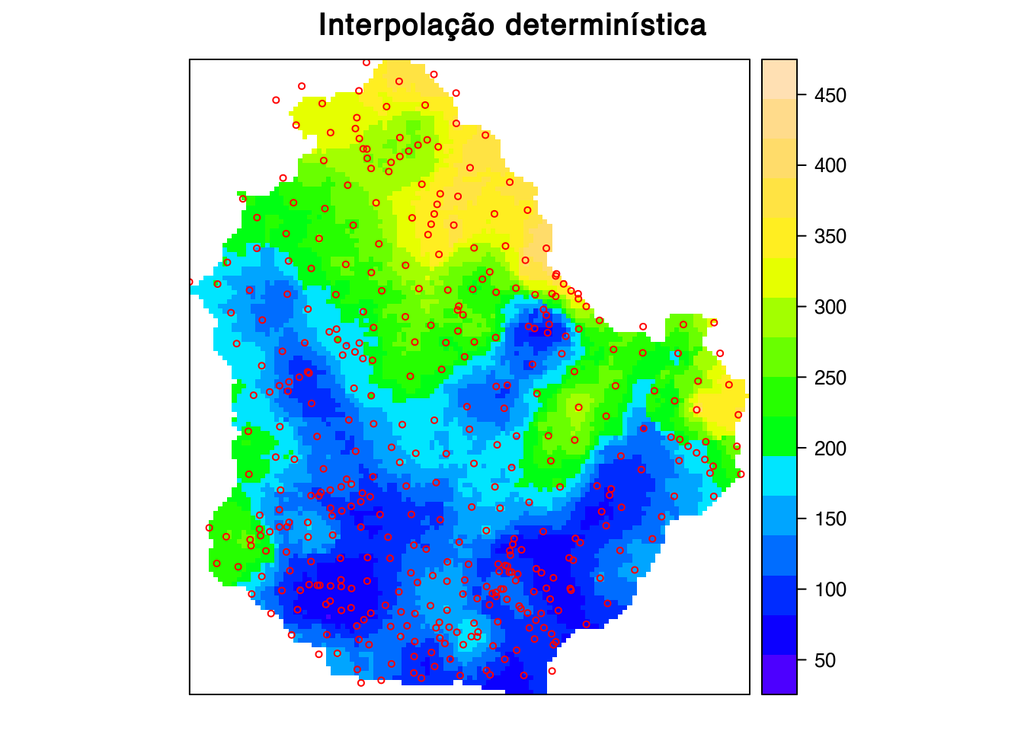

```r
sp::gridded(mapa_idw) <- TRUE
sp::spplot(mapa_idw, 'argila.pred', col.regions = col_soil_var,
           main = "Interpolação determinística") +
  latticeExtra::as.layer(lattice::xyplot(
    coord_y ~ coord_x, data = pontos400@coords %>% as.data.frame(),
    pch = 21, col = 'red', cex = 0.5))
```

## Modelo contínuo: visão estocástica

Vamos retomar o gráfico de bolhas para observar a existência de dependência espacial entre os valores da variável de interesse das observações do solo.

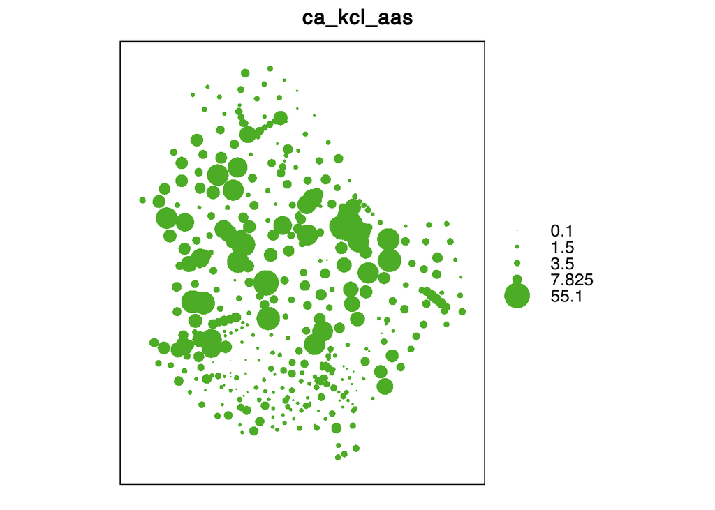

```r
sp::bubble(pontos400, 'ca_kcl_aas')
```

Como quantificar a dependência espacial?

Semivariograma (nuvem)

[figure not shown]

```r
variograma <- gstat::variogram(ca_kcl_aas ~ 1, pontos400, cloud = TRUE, cutoff = Inf)
plot(variograma, ylab = "Semivariância", xlab = "Distância (m)", main = "Nuvem semivariográfica") +
  latticeExtra::layer(lattice::panel.abline(h = var(pontos400$ca_kcl_aas), col = 'red'))
```

Semivariograma empírico suavizado

Parâmetros do semivariograma:

- Variância total (patamar)
- Variância residual (pepita)
- Alcance

[figure not shown]

```r
limites <- seq(0, 1500, length.out = 15)
variograma <- gstat::variogram(ca_kcl_aas ~ 1, pontos400, boundaries = limites)
plot(variograma, ylim = c(0, 175), ylab = "Semivariância", xlab = "Distância (m)",
     main = "Semivariograma empírico") +
  latticeExtra::layer(lattice::panel.text(variograma$dist, variograma$gamma, variograma$np, pos = 3))
```

- Puro ruído (sem estrutura)
- Exponencial (com patamar e alcance)
- Gaussiana (com patamar e alcance)

[figure not shown]

```r
limites <- seq(0, 1500, length.out = 15)
variograma <- gstat::variogram(ca_kcl_aas ~ 1, pontos400, boundaries = limites)
m_exp <- gstat::vgm(psill = 100, model = 'Exp', range = 500, nugget = 20)
m_gau <- gstat::vgm(psill = 80, model = 'Gau', range = 400, nugget = 25)
m_nug <- gstat::vgm(psill = 100, model = 'Nug', range = 0, nugget = 0)
plot(variograma, ylim = c(0, 175), ylab = "Semivariância", xlab = "Distância (m)",
     main = "Três modelos do semivariograma") +
  latticeExtra::layer(lattice::panel.lines(
    gstat::variogramLine(m_exp, dist_vector = seq(0, 1500, length.out = 1500)), col = "darkgreen")) +
  latticeExtra::layer(lattice::panel.lines(
    gstat::variogramLine(m_gau, dist_vector = seq(0, 1500, length.out = 1500)), col = "orange")) +
  latticeExtra::layer(lattice::panel.lines(
    gstat::variogramLine(m_nug, dist_vector = seq(0, 1500, length.out = 1500)), col = "purple")) +
  latticeExtra::layer(lattice::panel.text(
    rep(10, 3), seq(130, 160, length.out = 3), c('Exponencial', 'Gaussiana','Puro ruído'),
    col = c('darkgreen', 'orange', 'purple'), pos = 4))
```

Vejamos o que cada uma dessas funções representa no mundo real.

```r
v <- gstat::gstat(formula = z ~ 1, dummy = TRUE, beta = 0, model = m_gau, nmax = 10)
simula <- predict(v, grid, nsim = 1)
```

```
## [using unconditional Gaussian simulation]
```

```r
v <- gstat::gstat(formula = z ~ 1, dummy = TRUE, beta = 0, model = m_exp, nmax = 10)
simula$Exp <- predict(v, grid, nsim = 1)$sim1
```

```
## [using unconditional Gaussian simulation]
```

```r
v <- gstat::gstat(formula = z ~ 1, dummy = TRUE, beta = 0, model = m_nug, nmax = 10)
simula$Nug <- predict(v, grid, nsim = 1)$sim1
```

```
## [using unconditional Gaussian simulation]
```

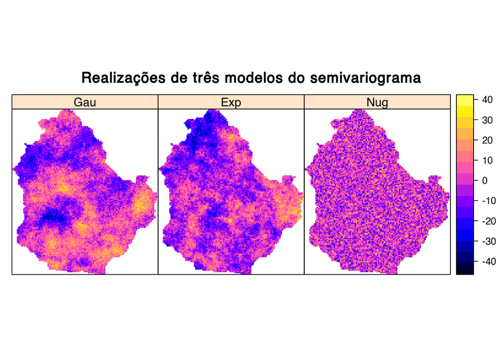

```r
names(simula)[1] <- 'Gau'
sp::gridded(simula) <- TRUE
sp::spplot(simula, main = "Realizações de três modelos do semivariograma")
```

Vejamos outras funções existentes.

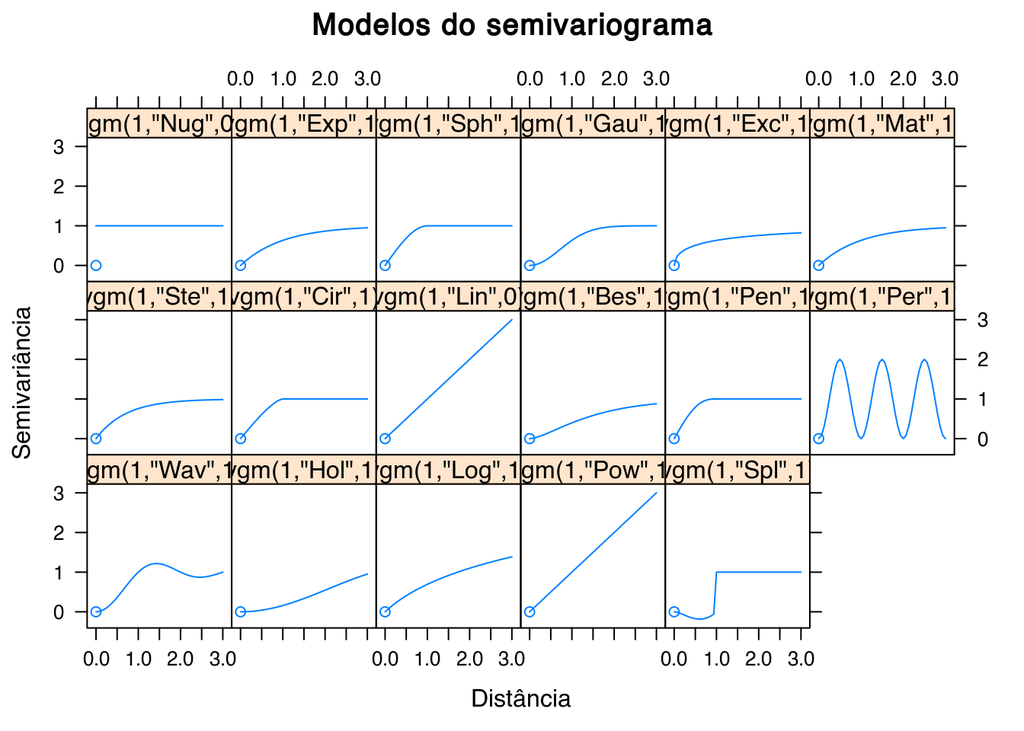

```r
gstat::show.vgms(main = "Modelos do semivariograma", xlab = "Distância", ylab = "Semivariância")
```

Ajuste do modelo ao variograma empírico

[figure not shown]

```r
m_exp <- gstat::fit.variogram(variograma, m_exp)
plot(variograma, m_exp, col.line = 'red', main = "Modelo exponencial ajustado ao semivariorgama") +
  latticeExtra::layer(lattice::panel.abline(v = m_exp$range, lty = 'dashed')) +
  latticeExtra::layer(lattice::panel.abline(h = m_exp$psill, lty = 'dashed')) +
  latticeExtra::layer(lattice::panel.text(
    y = m_exp$psill + 4, x = c(10, 10), c('Pepita', 'Patamar'), pos = 4)) +
  latticeExtra::layer(lattice::panel.text(
    y = 50, x = m_exp$range[2], 'Alcance', pos = 4, srt = 270))
```

Predições espaciais

```r
mapa_exp <- gstat::krige(ca_kcl_aas ~ 1, pontos400, grid, m_exp)
```

```
## [using ordinary kriging]
```

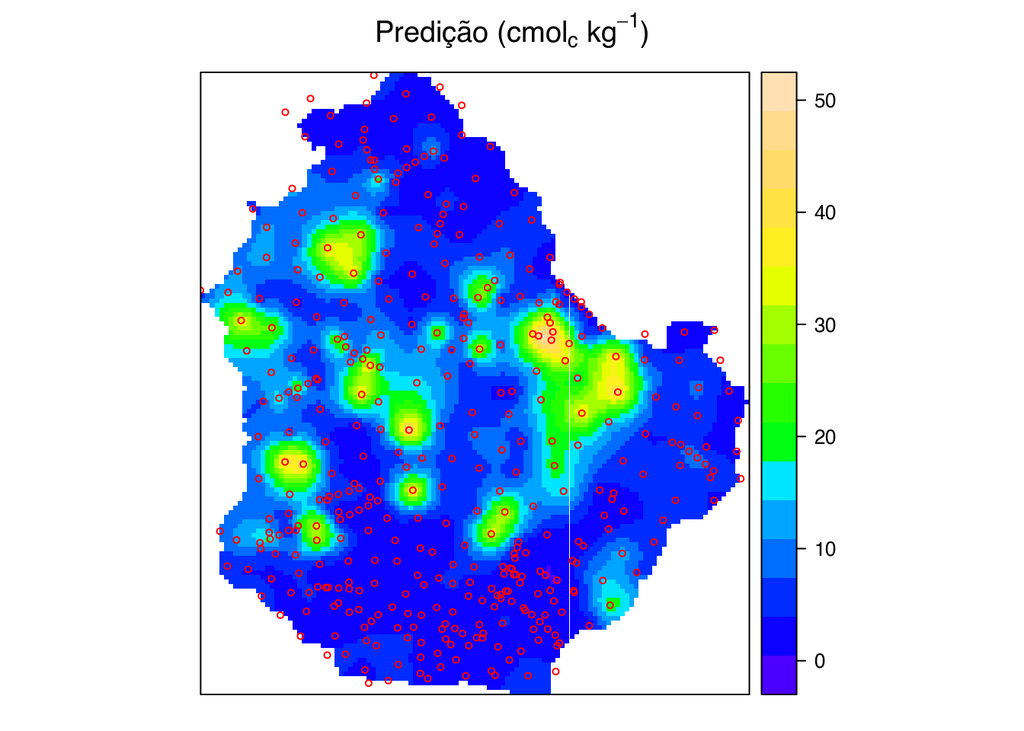

```r
mapa_exp$var1.var <- sqrt(mapa_exp$var1.var)
sp::gridded(mapa_exp) <- TRUE
sp::spplot(mapa_exp, 1, col.regions = col_soil_var, main = expression("Predição (cmol"[c]*" kg"^-1*")")) +
  latticeExtra::as.layer(lattice::xyplot(
    coord_y ~ coord_x, data = pontos400@coords %>% as.data.frame(), pch = 21, col = 'red', cex = 0.5))
```

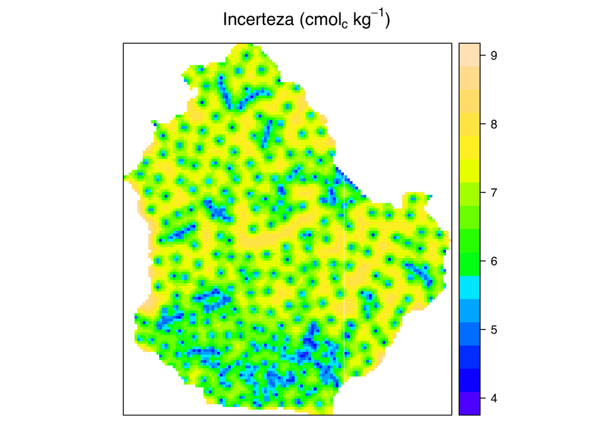

```r
sp::spplot(mapa_exp, 2, col.regions = col_soil_var, main = expression("Incerteza (cmol"[c]*" kg"^-1*")"))
```

```r
limites <- seq(0, 1500, length.out = 15)
variograma <- gstat::variogram(ca_kcl_aas ~ 1, pontos400, boundaries = limites)
lattice::xyplot(
  rep(variograma$gamma, each = 2) ~ rep(limites, each = 2)[-c(1, 30)], type = 'l',
  ylab = "Semivariância", xlab = "Distância (m)", ylim = c(0, 175), xlim = c(0, 1500)) +
  latticeExtra::layer(lattice::panel.text(limites + diff(limites[1:2]) / 2, variograma$gamma, variograma$np, pos = 3)) +
  latticeExtra::layer(lattice::panel.abline(h = var(pontos400$ca_kcl_aas), col = 'red', lty = 'dashed')) +
  latticeExtra::layer(lattice::panel.segments(y0 = rep(0, 15), y1 = variograma$gamma, x0 = limites, x1 = limites)) +
  plot(variograma) %>% latticeExtra::as.layer()
```

[output not shown]